# Prosper Loan Data Exploration

## Ghada Bin Muhareb

## Investigation Overview

I'm interested in invetigating the Borrower Annual Percentage Rate (APR) and take a closer look to explore which variables can correlat and affect the Borrower (APR) through visualizations.

## Dataset Overview

This dataset contains 113,937 loans with 81 variables on each loan, including loan amount, borrower rate (or interest rate), current loan status, borrower income, and many others. Since the dataset includes 81 variables it is difficult to invistigate all of them, so only few of them will be explored.

## The distribution of Borrower APR

Borrower APR distribution looks multimodal and take a wide range. There is a small peak around 0.1, at 0.2 there is a larger peak, at 0.3 we also have a small peak. Looking at the point between 0.35 and 0.36 we will find a very sharp peak. There are only few loans with APR greater than 0.4.

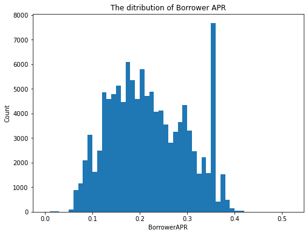

```python
bins = np.arange(0, loans['BorrowerAPR'].max()+0.01, 0.01)
plt.figure(figsize=[8,6])
plt.hist(data=loans, x='BorrowerAPR', bins=bins)
plt.title('The ditribution of Borrower APR')
plt.xlabel('BorrowerAPR');
plt.ylabel('Count');
```

## The distribution of the Prosper Rates

Most of the borrowers have a rating of C which is in the middle, and we can say most of them fall within the range D-A.

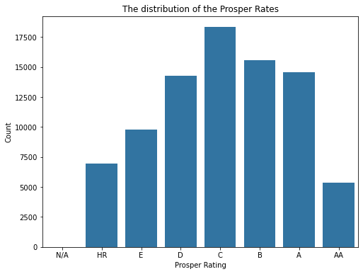

```python
base_color = sb.color_palette()[0]
plt.figure(figsize=[8,6])
sb.countplot(data=loans, x='ProsperRating', color=base_color, order=['N/A', 'HR', 'E', 'D', 'C', 'B', 'A', 'AA']);
plt.title('The distribution of the Prosper Rates');
plt.xlabel('Prosper Rating');
plt.ylabel('Count');
```

## The distribution of the Employment Status

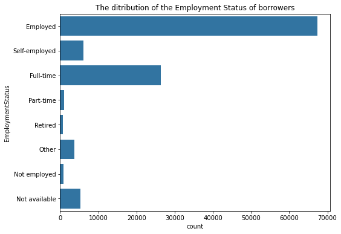

```python
base_color = sb.color_palette()[0]
plt.figure(figsize=[8,6])
sb.countplot(data=loans, y='EmploymentStatus', color=base_color, order=['Employed', 'Self-employed', 'Full-time', 'Part-time', 'Retired', 'Other', 'Not employed', 'Not available'])
plt.title('The ditribution of the Employment Status of borrowers');
```

## The distribution of the Estimated Return of each loan

The Estimated Return looks normally distributed, the highest Estimated Return is centered at 0.08 and there is very few loans with Estimated Return less than zero.

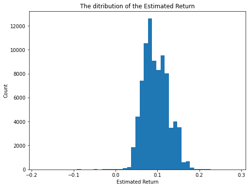

```python
bins = np.arange(-0.182700, loans['EstimatedReturn'].max()+0.01,0.01)
plt.figure(figsize=[8,6])
plt.hist(data=loans, x='EstimatedReturn', bins=bins)
plt.title('The ditribution of the Estimated Return')
plt.xlabel('Estimated Return');
plt.ylabel('Count');
```

## Loan Original Amount Vs. Borrower APR

There is a negative relationship between the Loan Original Amount and the Borrower APR, as the original amount of the loan was high the Borrower annual percentage rate (APR) will be low.

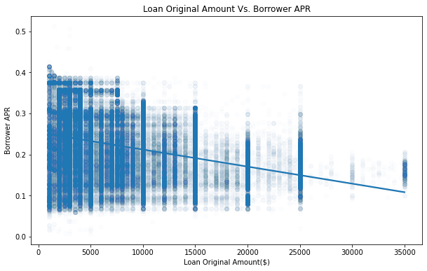

```python
plt.figure(figsize=[10,6])
sb.regplot(data=loans, x='LoanOriginalAmount', y='BorrowerAPR', x_jitter=0.9, scatter_kws={'alpha':0.01});
plt.title('Loan Original Amount Vs. Borrower APR');
plt.xlabel('Loan Original Amount($)');
plt.ylabel('Borrower APR');
```

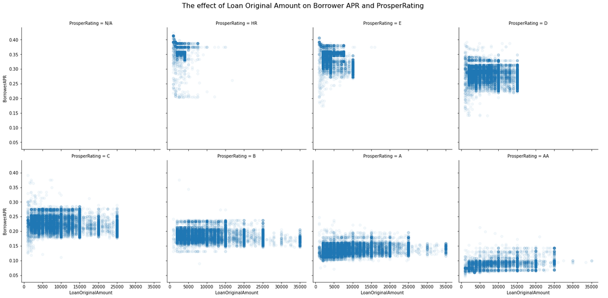

```python
g=sb.FacetGrid(data=loans, col='ProsperRating', size=5, col_wrap=4)
g.map(plt.scatter, 'LoanOriginalAmount', 'BorrowerAPR', alpha=0.05);
g.add_legend();
plt.subplots_adjust(top=0.9)
g.fig.suptitle('The effect of Loan Original Amount on Borrower APR and ProsperRating', fontsize=16);
```

## Prosper Rating Vs. Borrower (APR) considering Employment Status

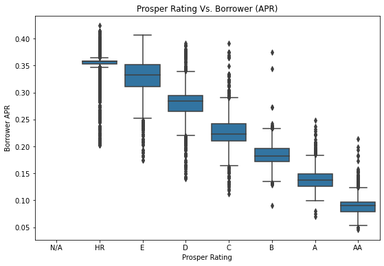

```python
base_color = sb.color_palette()[0]
plt.figure(figsize=[9,6])
rate_classes = ['N/A', 'HR', 'E', 'D', 'C', 'B', 'A', 'AA']
rates = pd.api.types.CategoricalDtype(ordered=True, categories=rate_classes)
loans['ProsperRating'] = loans['ProsperRating'].astype(rates);
sb.boxplot(data=loans, x='ProsperRating', y='BorrowerAPR', color=base_color);
plt.title('Prosper Rating Vs. Borrower (APR)');
plt.xlabel('Prosper Rating');
plt.ylabel('Borrower APR');
```

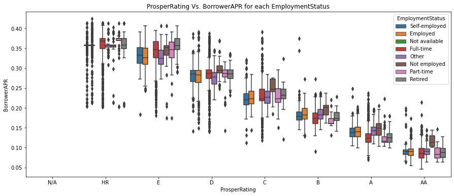

```python
plt.figure(figsize=[15,6])
sb.boxplot(data = loans, x = 'ProsperRating', y = 'BorrowerAPR', hue = 'EmploymentStatus');
plt.title('ProsperRating Vs. BorrowerAPR for each EmploymentStatus');
```

## Prosper ratings Vs. Employment Status

Most of the borrowers are as shown before employed and the rating (C) includes the largest group of the borrowers. (Part-time, Retired and Not employed) groups are the lowest for all types of rating.

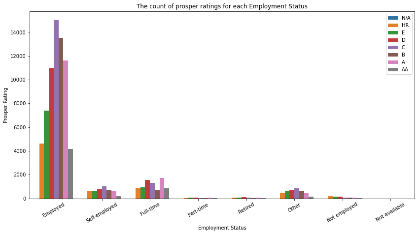

```python
plt.figure(figsize = [14,7])
sb.countplot(data = loans, x = 'EmploymentStatus' , hue = 'ProsperRating',
             order=['Employed', 'Self-employed', 'Full-time', 'Part-time', 'Retired', 'Other', 'Not employed', 'Not available']);
plt.xticks(rotation=30);
plt.legend(loc='upper right');
plt.title('The count of prosper ratings for each Employment Status');
plt.xlabel('Employment Status');
plt.ylabel('Prosper Rating');
```

## Income Range Vs. Prosper Rating

Most of the borrower ratings are located within the income range 25,000-49,999 to 50,000-74,999, some of them are greater than 74,999 and only very few of them are located in the income range 1-24,999.

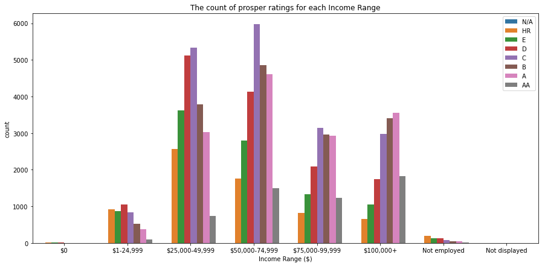

```python
order = ['$0', '$1-24,999', '$25,000-49,999', '$50,000-74,999', '$75,000-99,999', '$100,000+', 'Not employed', 'Not displayed']
plt.figure(figsize = [15,7])
sb.countplot(data = loans, x = 'IncomeRange' , hue = 'ProsperRating', order=order);
plt.legend(loc='upper right');
plt.xlabel('Income Range ($)');
plt.title('The count of prosper ratings for each Income Range');
```

## The interaction between loan terms and ratings for the Loan Original Amount

There is an obvious interaction between loan terms and ratings. As much as the Prosper ratings getting higher or better, the loan original amount of all three loan terms getting increased, since the loan original amount increased the term of loans also increases.

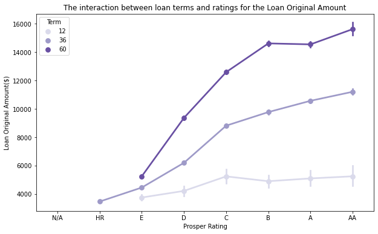

```python
plt.figure(figsize=[10,6])
sb.pointplot(data = loans, x = 'ProsperRating', y = 'LoanOriginalAmount', hue = 'Term',
           palette = 'Purples', order=['N/A', 'HR', 'E', 'D', 'C', 'B', 'A', 'AA']);

plt.title('The interaction between loan terms and ratings for the Loan Original Amount');
plt.xlabel('Prosper Rating');
plt.ylabel('Loan Original Amount($)');
```

## Comparing Estimated Return with Borrower APR for each Prosper Rating

The highest ratings of the borrower is the lowest Annual Percentage Rate (APR) with almost the same estimatd return, except the lowest rating (HR) which has lower estimatd return and higher Annual Percentage Rate (APR). The highest Estimated Return acheived almost in the Ratings (E,D and C).

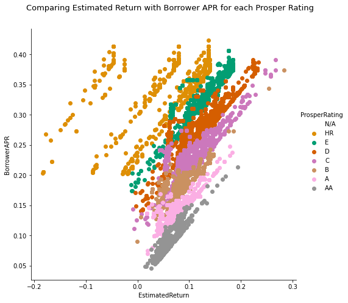

```python
g = sb.FacetGrid(data = loans, hue = 'ProsperRating', size = 7,
                 palette = 'colorblind');
g.map(plt.scatter, 'EstimatedReturn', 'BorrowerAPR');
g.add_legend();
plt.subplots_adjust(top=0.9)
g.fig.suptitle('Comparing Estimated Return with Borrower APR for each Prosper Rating', fontsize=13);
```

### Key Insights

- As much as the borrowers choose a higher loan original amount this will contribute to decrease the Anuual Percentage Reate (APR).
- Higher prosper ratings of borrowers allow for larger loan original amount and longer term.
- Lower prosper ratings lead to higher Annual Percentage Rate (APR).
- The highest Estimated Return acheived almost in the Ratings (E,D and C).